# Estimated Delivery Date Prediction

Khaled Jafar

July 30th, 2016

### **Project overview**:

The goal of this project is to create a machine learning algorithm that can be implemented real time into the order process to provide customers with the best delivery date target. The delivery date would be provided to the customer at the time the order is placed.

### **Problem statement**:

The current method of setting the estimated delivery date for customer orders is a manual process that results in ~60% of orders arriving within the delivery window with a high number of orders arriving early to the customer site. Early order arrivals can create issues for customer especially when customers are not prepared to receive the orders.

There have been several attempts to improve delivery date accuracy, but these attempts have resulted in only incremental improvements in our ability to deliver orders within the delivery window.

The goal of this project is to leverage key information about the order, customer, payment process, manufacturing process and logistics network to provide the customer with the most accurate delivery date. The approach will be to understand which variables (over 100 variables are collected at time of order receipt) have the greatest impact on delivery date and to build a model that utilizes the most impactful variables to accurately predict delivery date more than 80% of the time without a negative impact to late deliveries.

### **Metrics**:

The key metrics that will be used to measure success of this project are the following:

1. Order On-time %: % of orders that are delivered within the delivery date window provided to the customer. The desire is to have this number exceed 80%. This metric will be measured in the following way: (orders that are delivered within the delivery window communicated to the customer/ total orders)
2. Order Late %: % of orders that are delivered late to the delivery date window provided to the customer. The desire is to have this number below 5%. This metric will be measured in the following way: (qty orders that are delivered late to delivery date communicated to the customer/ total orders)

### **DATA Wrangling**.

Below is a list of the steps that were taken to wrangle and prepare the data for analysis:

1. Pulled in the required data from the SQL server into R
2. Converted date columns into dates since some of them show up as factors
3. Needed to create a new column for 1st attempt delivery date based on 2 other columns
   - POI_Delivery_Date_1st_Attempt_SD_DD
   - Delivery_Attempt_1. The first step was to take the date from POI_Delivery_Date_1st_Attempt_SD_DD when it is not null and then take the date from Delivery_Attempt_1 column when the date in POI_Delivery_Date_1st_Attempt_SD_DD is null
4. Calculated the number of business days delta for the for the following:
   - From Order Date to Estimated Delivery Date (EDD)
   - From Order Date to 1st attempt delivery date
5. Calculated the business day delta between (Order Date - Delivery Date) - (Order Date - Estimated Delivery Date) to figure out when something is Late how many business days is Late and the same for Early.
6. Determined if each order is currently Early, Ontime or Late using window range rules

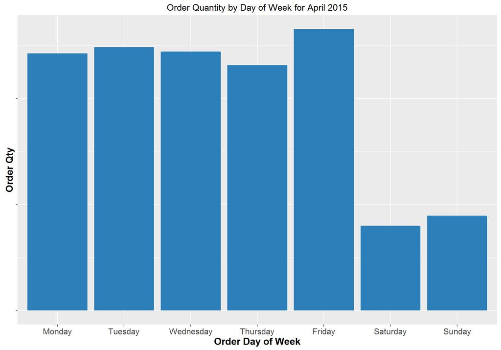

Consistent volume on weekdays with a big drop on weekends (weekends have ~30% of the weekday order volume)

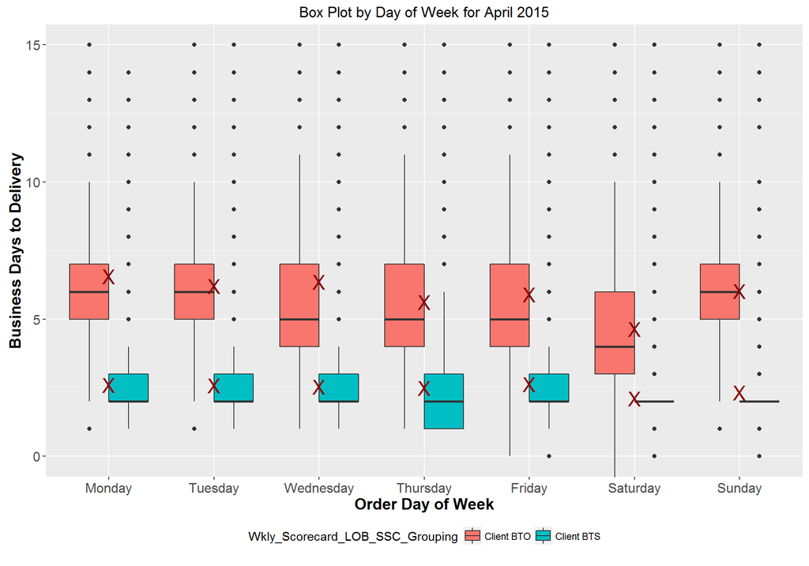

Client BTO consistently takes more time (as expected) thank Client BTS from order to delivery; for Client BTO Wed,Thursday and Friday has lower median but 3rd quartile similar to other days. Saturday is the execption with lower median and 3rd quartile. Posisbly due to having more time to build and stage before Monday.

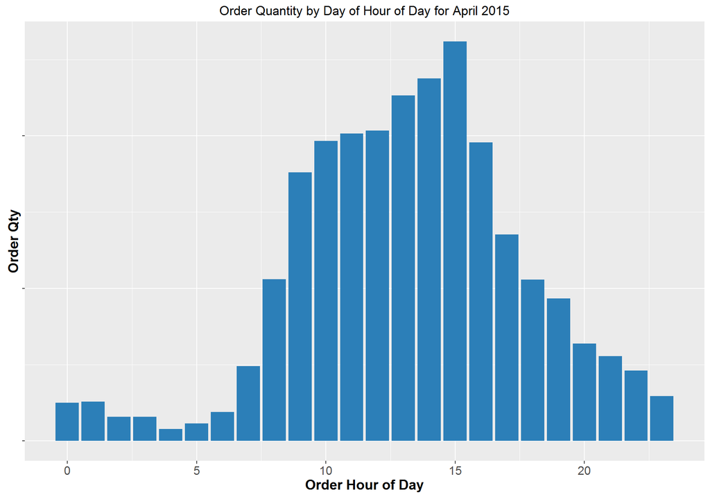

Majority of orders take place between 8AM and 5PM

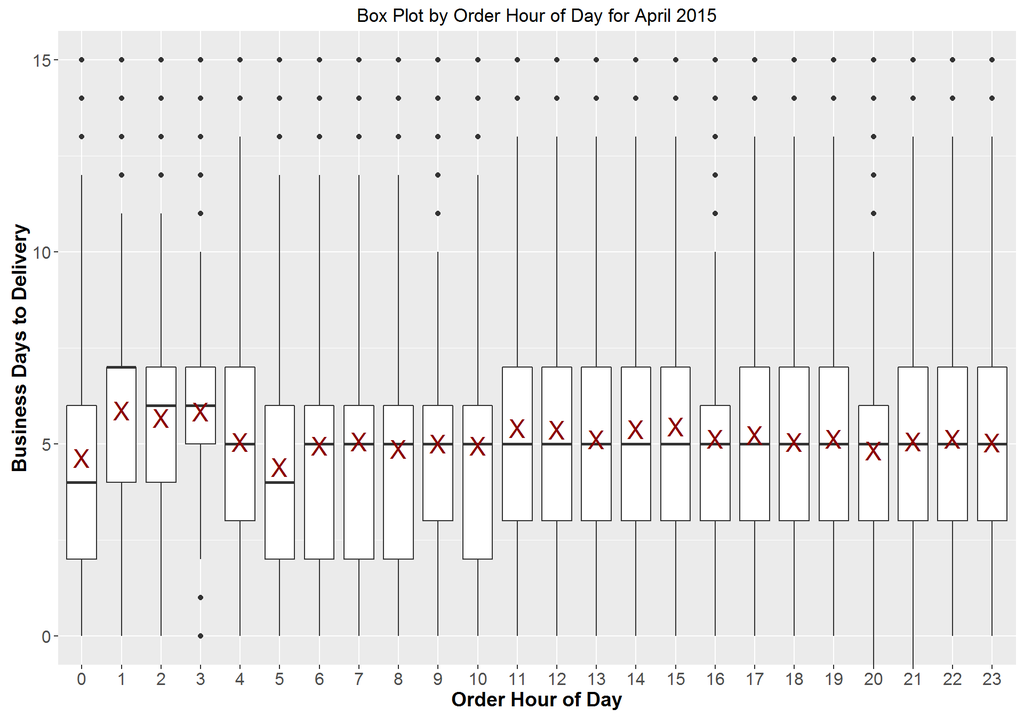

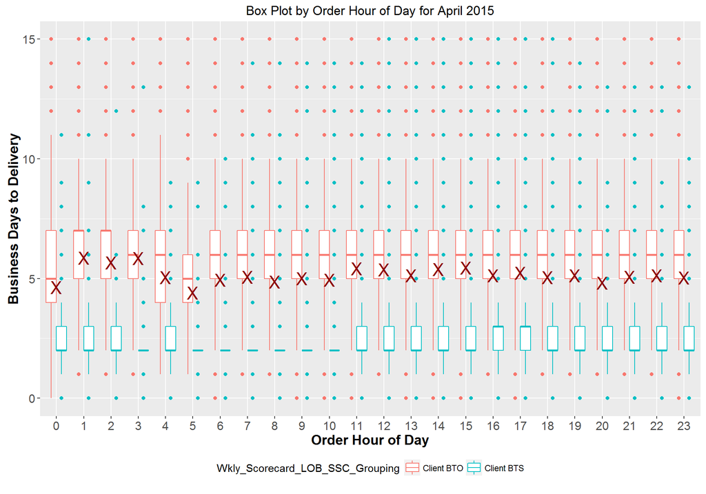

Another view by hour of Client BTO by hour of day, but see the consistent delta where BTO take more time than BTS as we would expect.

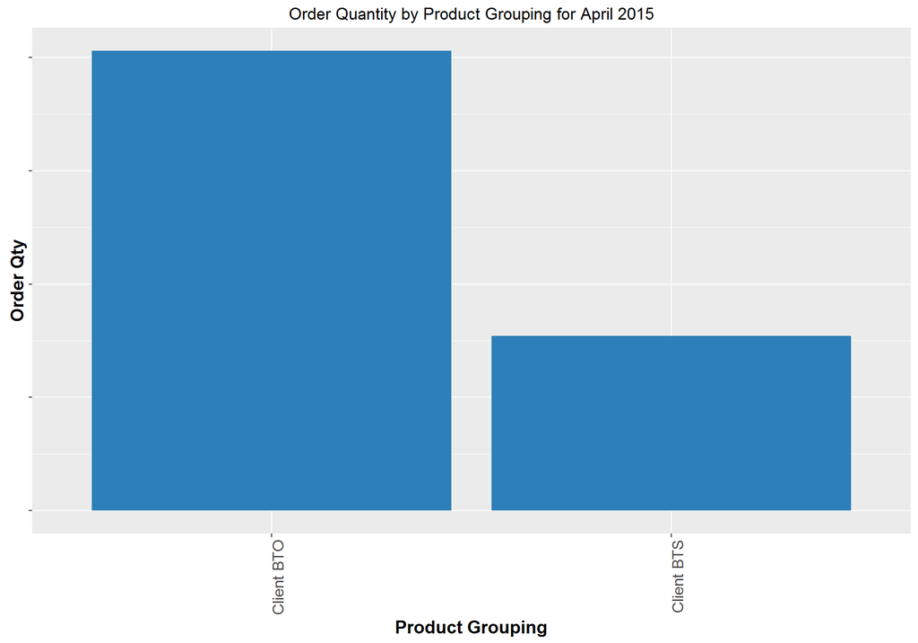

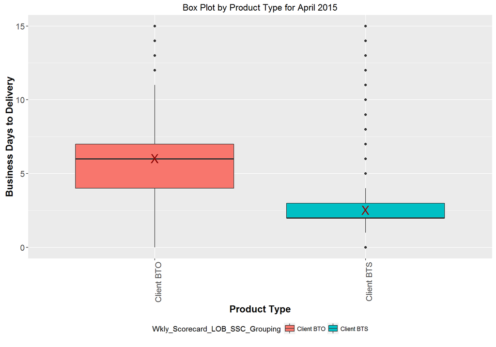

Client BTS has faster delivery time than Client BTO

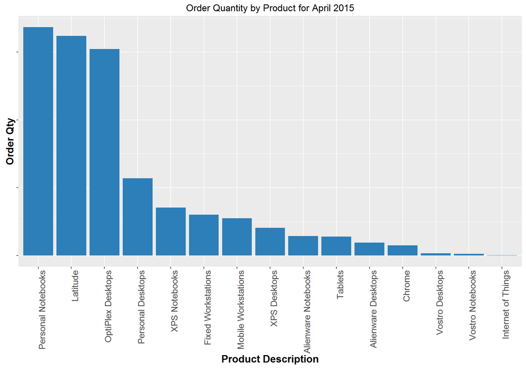

3 products (Latitude, OptiPlex Desktops and Personal Notebooks) driving ~70% of orders for the population.

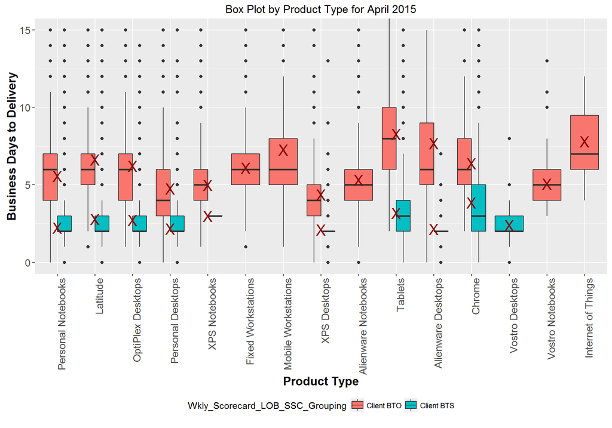

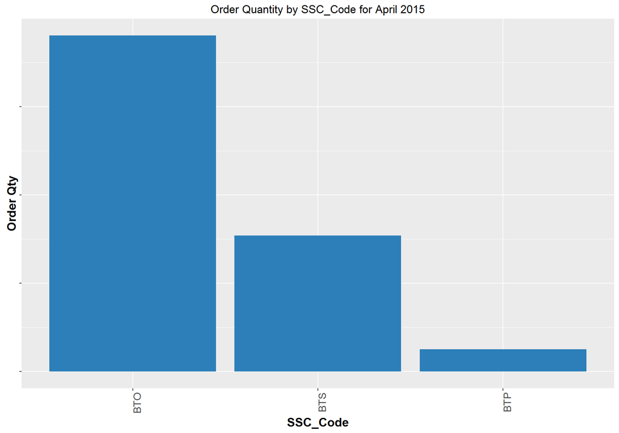

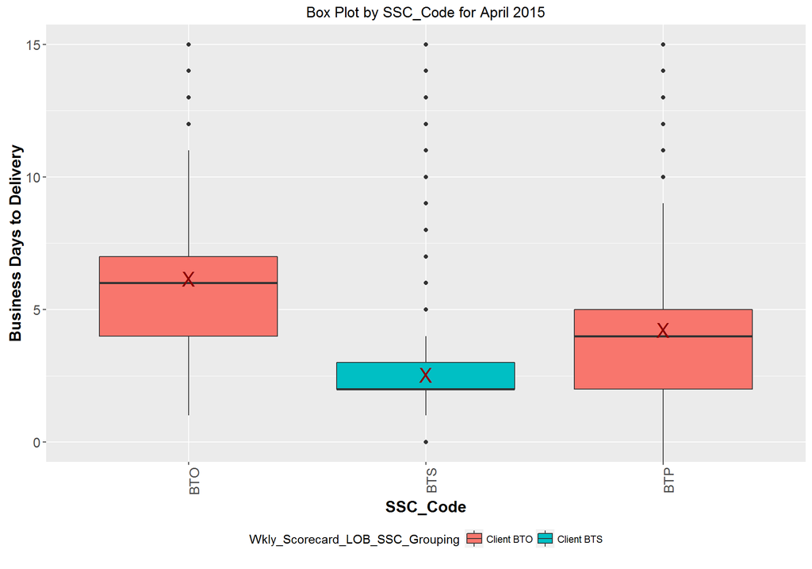

BTS has faster delivery time than BTO as expected

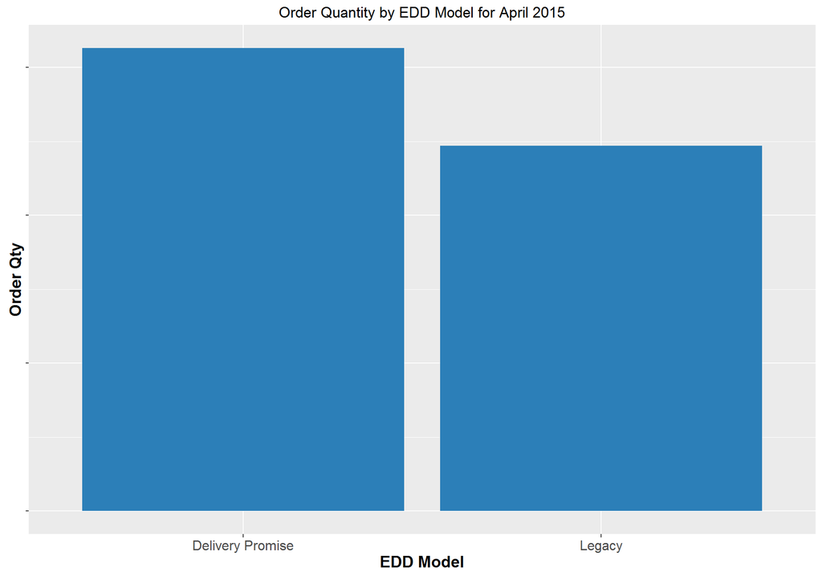

Delivery Promise orders is beginning to take on more importance as it now exceeds legacy orders.

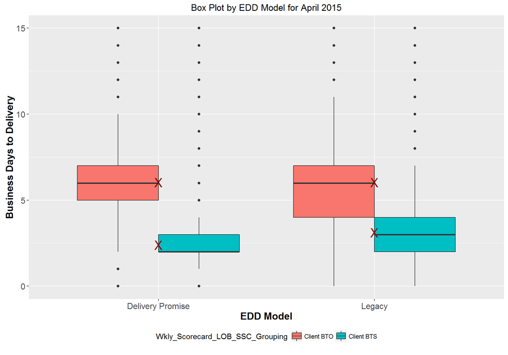

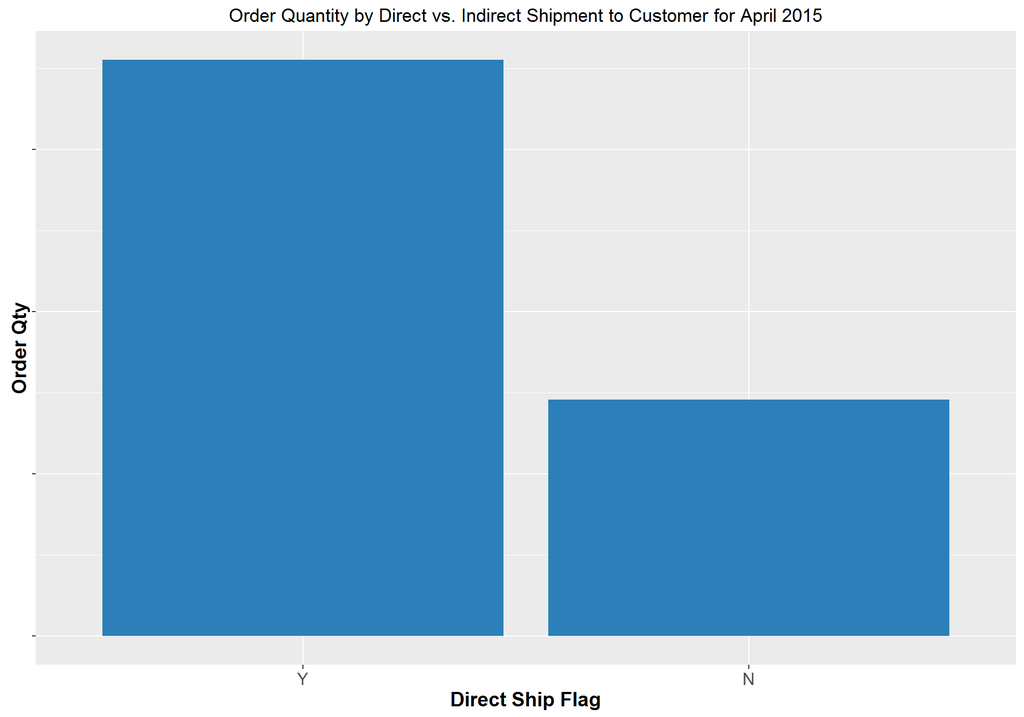

Greater number of orders are directly shipped to the customer and not sent to a merge center prior to shipment. We have 29.7K orders with null values for this flag …

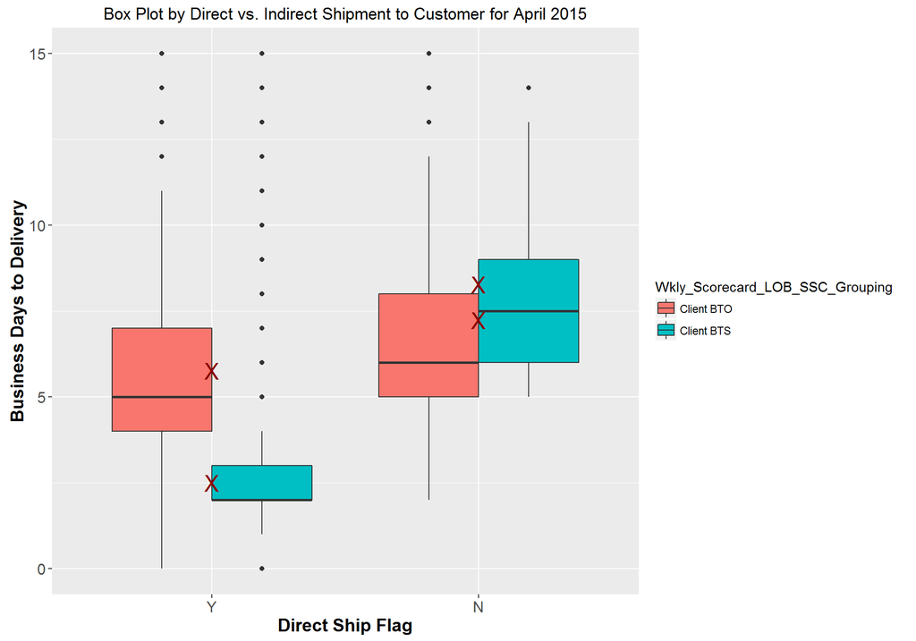

For non direct ship flag you see a higher number of business days for both BTO and BTS which is what you would expect since they are not being directly shipped to the customer

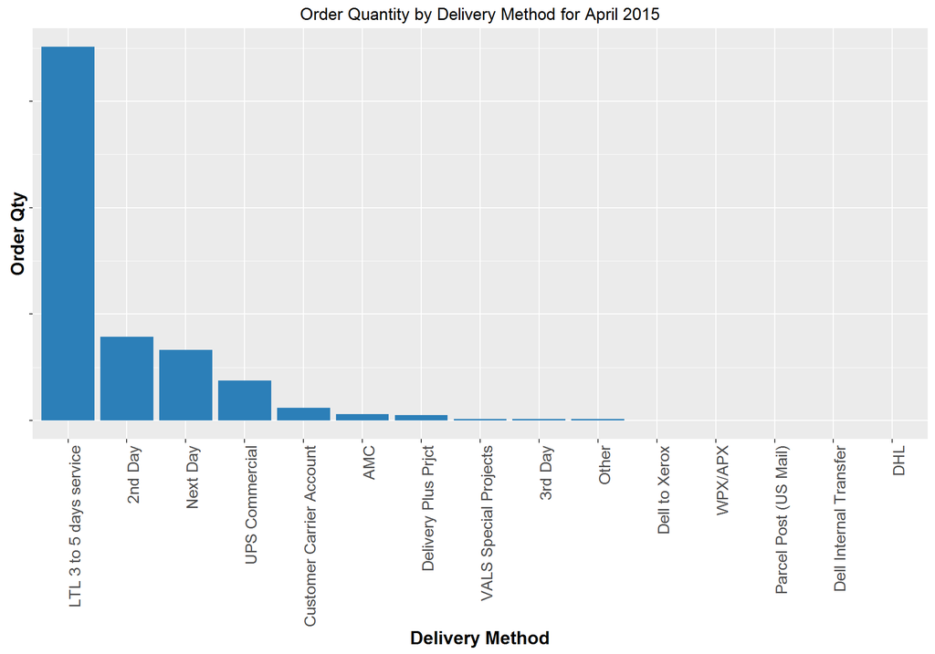

Majority of orders ~63% are through 3-5 days standard ground. 2nd Day and Next Day service round out the top 3 for a combined ~90% of all order deliveries.

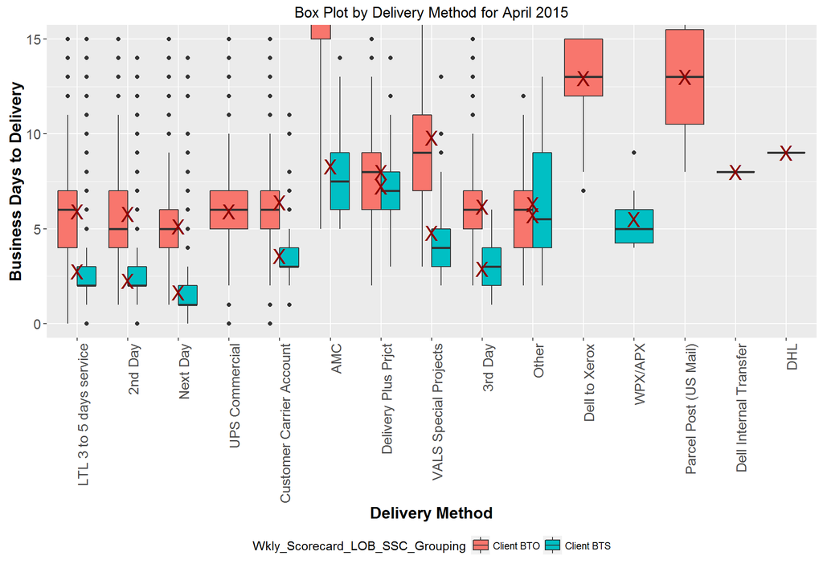

I found Delivery method to be interesting as I would have expected a bigger gap between 3 to 5 days ship method and 2 day ship method The median is lower on 2 day but the 25% to 75% is very similar. Next Day is lower as you would expect. This may be an area to explore

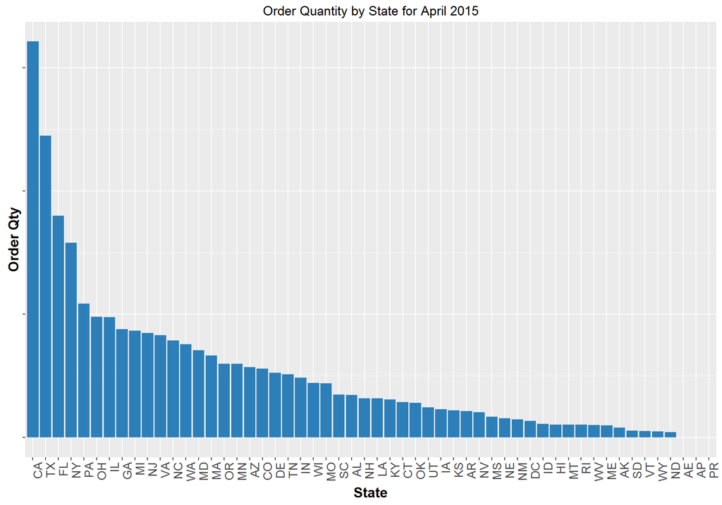

California , Texas and Florida, and New York are the top 4 states that orders are delivered to.

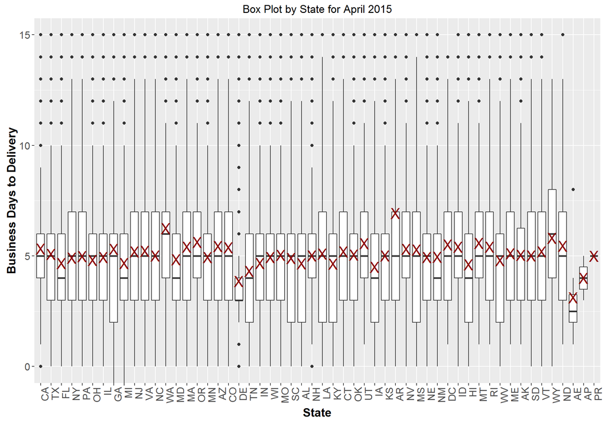

Florida (East Coast) runs faster than NY, TX and CA possibly due to the location of the distributions centers being closer to the east coast. State/Zip Code is likely to be a an important variable to consider.

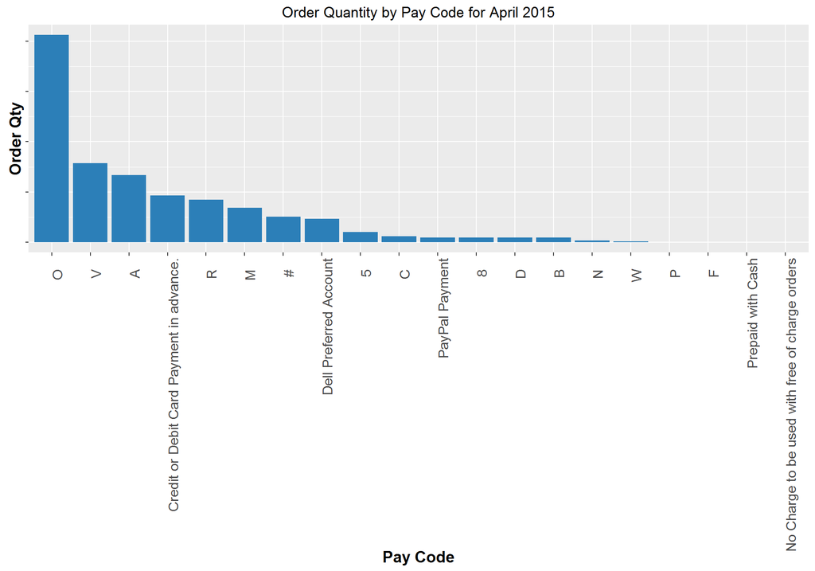

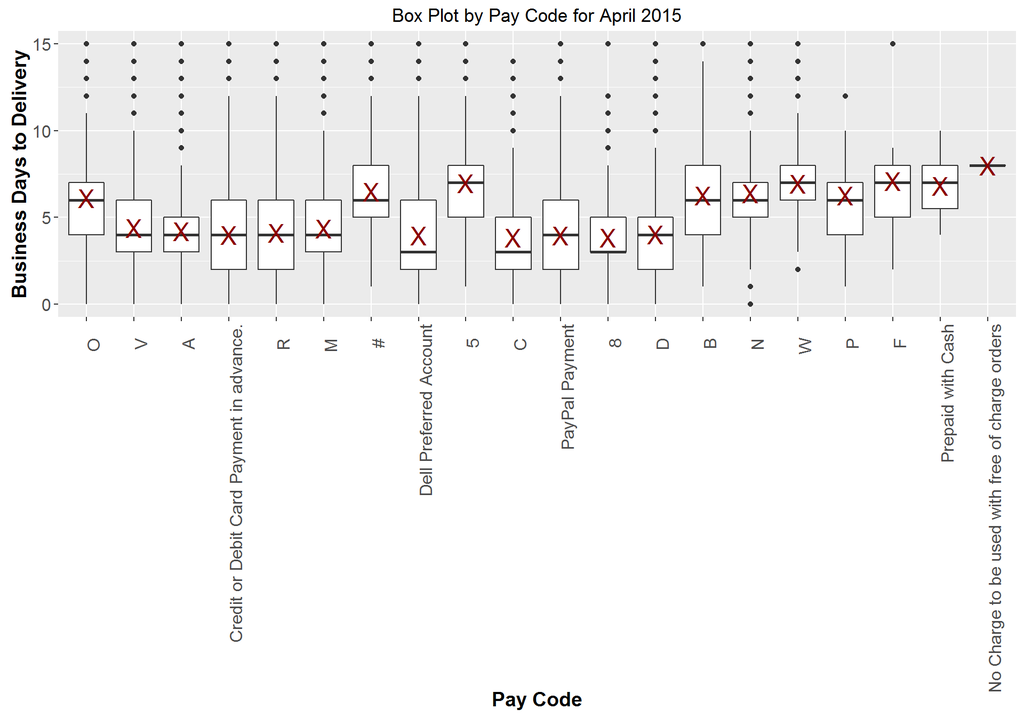

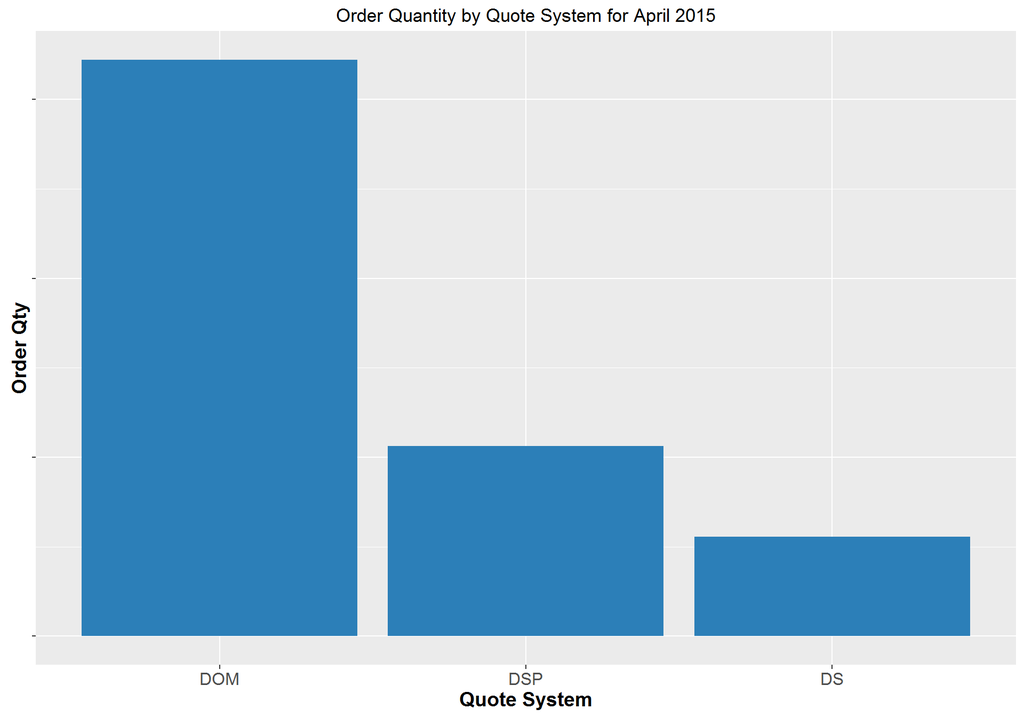

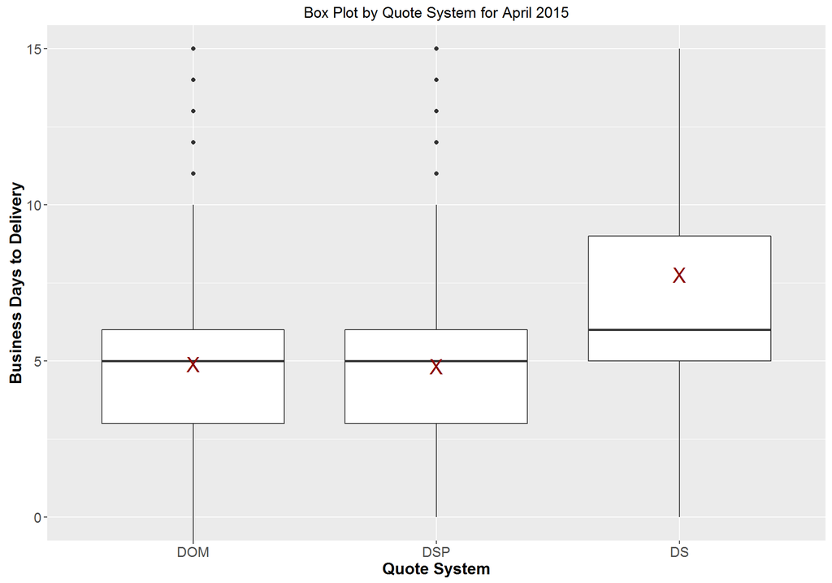

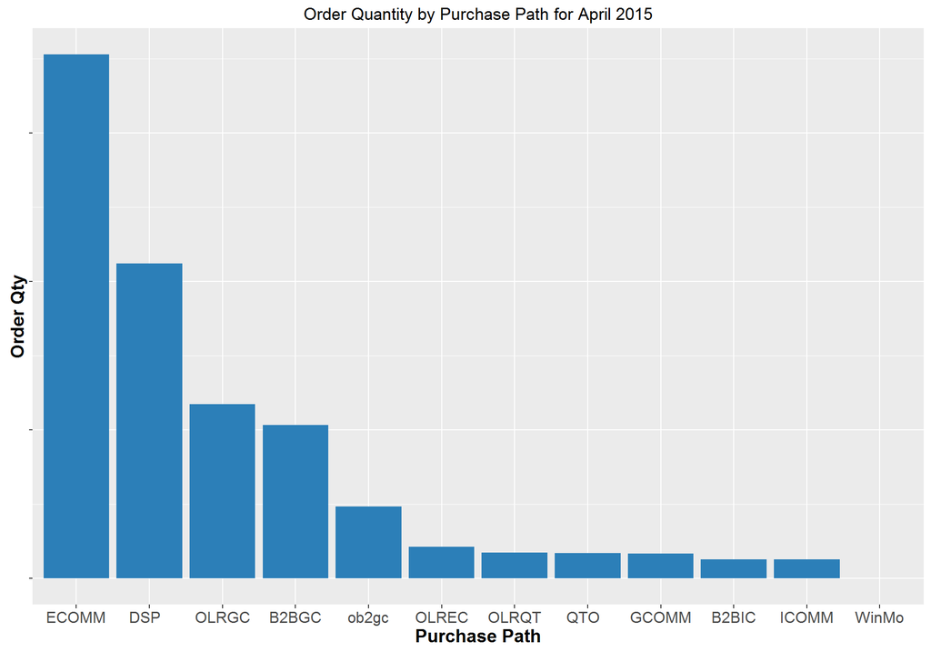

4 key purhase paths drive the majority of the orders; need to investigate NA values

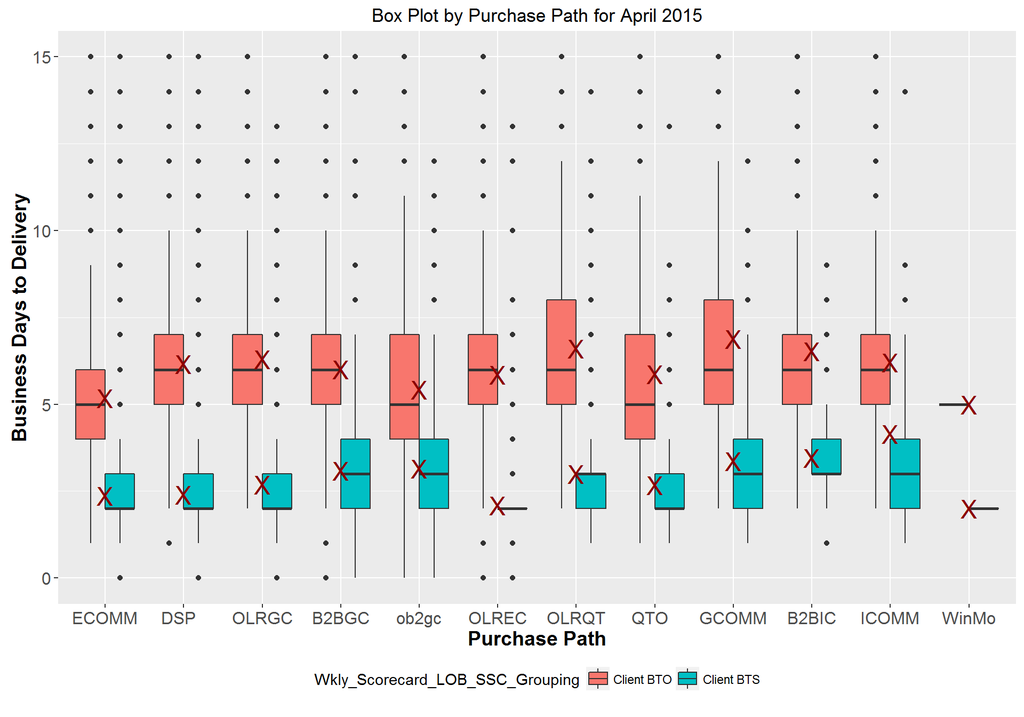

B2BGC and OB2GC purchase paths for BTS have a higher number of biz days

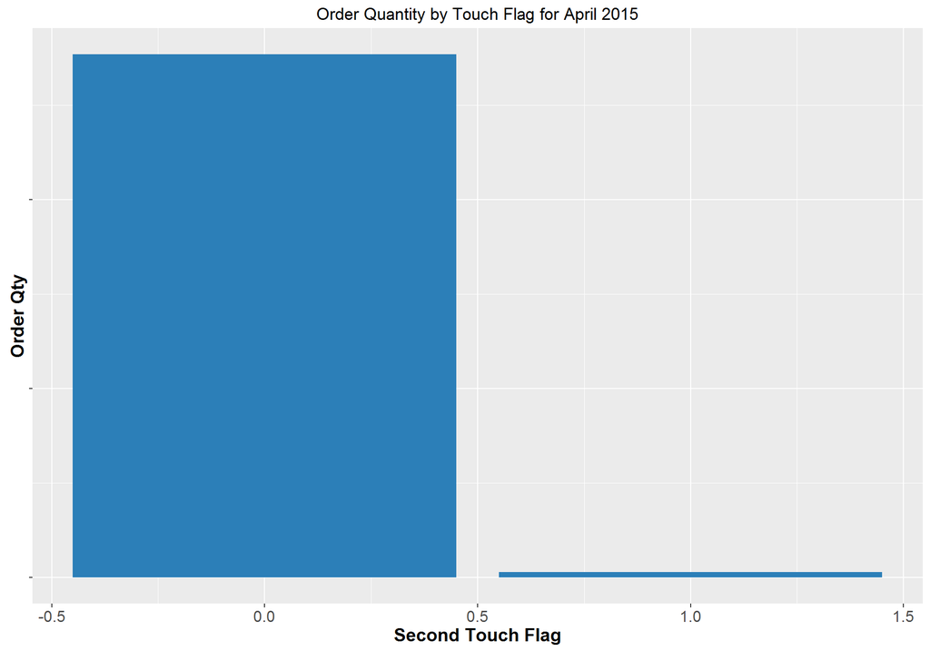

Very few orders ~1% of orders have a second touch applied to them.

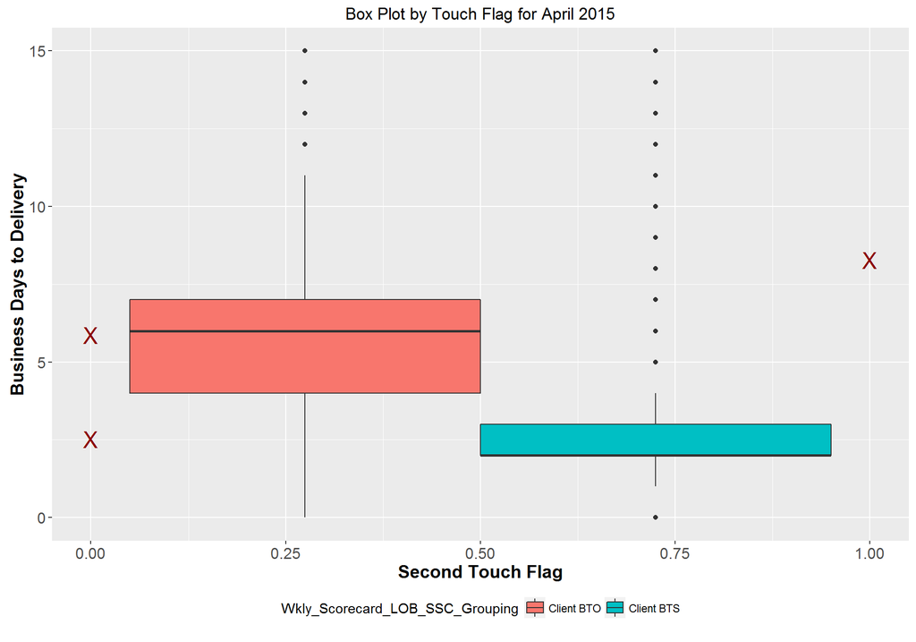

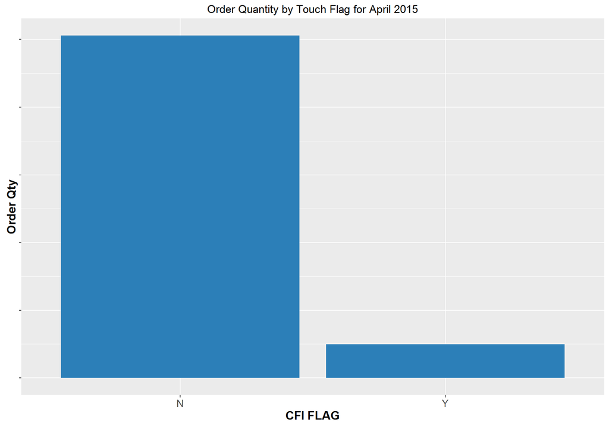

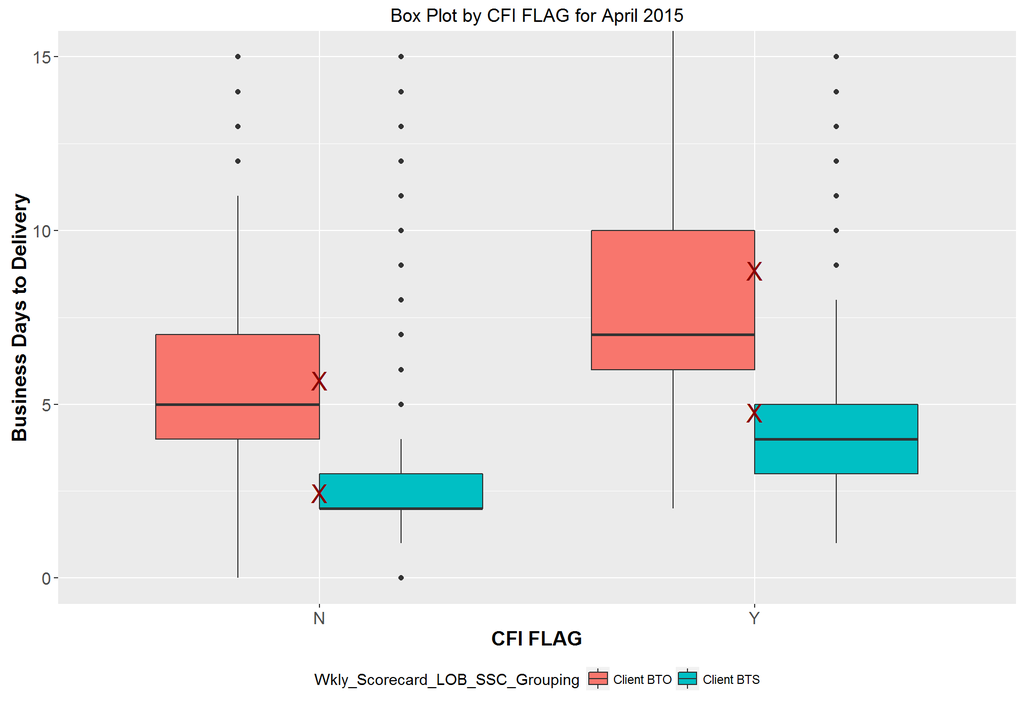

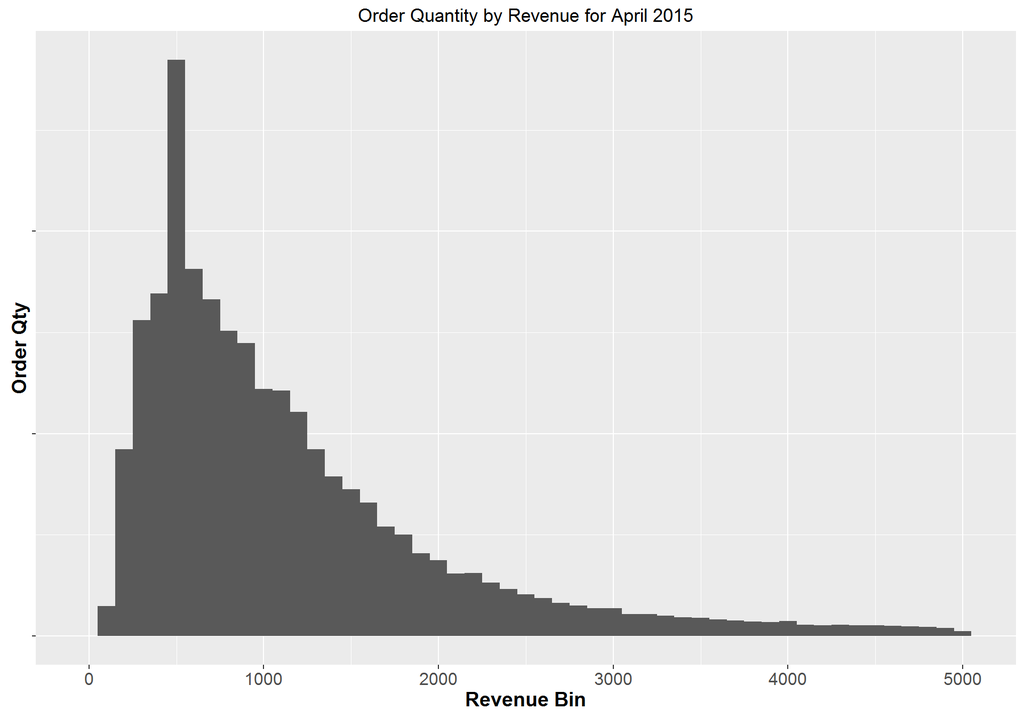

Majority of Orders are under $2K

[figure not shown]

As expected Client BTS has lower business days across price points.

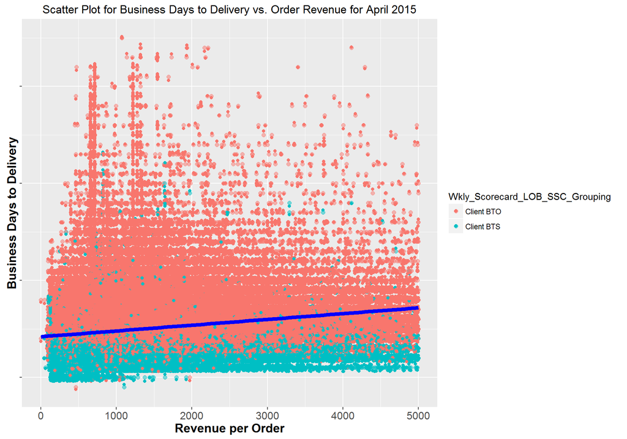